# Job Accessibility and Property Values in NYC: Did COVID-19 Reshape the Relationship?

- Show All Code
- Hide All Code
- View Source

# 1 Introduction

## 1.1 Connecting to the Overarching Question

Our team’s **Overarching Question (OQ)** asked: *Did COVID-19 reshape the relationship between neighborhood characteristics and property values across NYC’s Community Districts?* This question mattered because the pandemic fundamentally disrupted how Americans live, work, and value residential locations. Understanding these shifts has implications for urban planning, housing policy, and real estate investment decisions throughout New York City.

This individual analysis focused on one critical neighborhood characteristic: **job accessibility**, defined as the number of jobs within 1 kilometer of a neighborhood’s centroid. This metric captures the traditional urban economics principle that proximity to employment centers commands a premium in housing markets. The pandemic’s remote work revolution may have fundamentally weakened this long-standing relationship, as workers discovered they could perform their jobs from anywhere with an internet connection.

## 1.2 Specific Question

**Did the relationship between job accessibility and property values change from pre-COVID (2017-2019) to post-COVID (2021-2023)?**

This question was operationalized by calculating job accessibility for each of NYC’s 59 Community Districts using LODES employment data, measuring median property sale prices from DOF Rolling Sales data, comparing the correlation between these measures across the two periods, and testing whether any observed change in correlation was statistically significant. The analysis excluded 2020 to create a clean comparison between the pre-pandemic baseline and the post-pandemic period when new work patterns had stabilized.

## 1.3 Hypotheses

Based on the remote work hypothesis, the expected findings were: (H1) the positive correlation between job accessibility and property values weakened post-COVID; (H2) this weakening was more pronounced in Manhattan than outer boroughs due to its concentration of remote-capable white-collar jobs in finance, technology, and professional services; and (H3) neighborhoods with lower pre-COVID job accessibility experienced relatively higher price growth as location flexibility increased and workers could choose neighborhoods based on amenities rather than commute times.

These hypotheses were grounded in the bid-rent model from urban economics. Before the pandemic, workers faced a fundamental tradeoff between housing costs and commute times. Living near job centers meant shorter commutes but higher rents; living farther away saved money but imposed time costs. This tradeoff generated the classic bid-rent gradient where land prices decline with distance from employment centers. Remote work disrupts this equilibrium by reducing or eliminating commute costs, potentially flattening the bid-rent gradient and reducing the premium for job-accessible locations.

# 2 Data Acquisition

Data was acquired from multiple sources using programmatic methods to ensure reproducibility. All functions implemented caching to avoid repeated API calls and enable others to reproduce this analysis without redundant downloads. The data sources spanned multiple government agencies and required different access methods including REST APIs, web scraping, and paginated queries.

The primary data sources included: NYC Community District boundaries from the NYC Open Data portal; PLUTO parcel data linking properties to administrative geographies; DOF Rolling Sales providing transaction-level price data; LODES employment statistics from the Census Bureau enabling job counts at the census block level; ZIP Code Business Patterns for estimating recent employment trends; and ACS demographic data providing neighborhood context.

## 2.1 Community District Shapes (NYC Open Data API)

```r
get_cd_shapes <- function(dir_path = "data") {

  if (!dir.exists(dir_path)) dir.create(dir_path, recursive = TRUE)

  fname <- file.path(dir_path, "cd_shapes.rds")
  geojson_file <- file.path(dir_path, "cd_shapes.geojson")

  if (file.exists(fname)) {
    message("Using cached CD shapes: ", fname)
    return(readRDS(fname))
  }

  message("Downloading Community Districts from NYC ArcGIS API...")

  tryCatch({
    req <- request("https://services5.arcgis.com/GfwWNkhOj9bNBqoJ/arcgis/rest/services/NYC_Community_Districts/FeatureServer/0/query") |>
      req_url_query(
        where = "1=1",
        outFields = "*",
        outSR = "4326",
        f = "geojson"
      ) |>
      req_headers("User-Agent" = "Mozilla/5.0 (Windows NT 10.0; Win64; x64)")

    resp <- req_perform(req)

    writeLines(resp_body_string(resp), geojson_file)
    message("Saved GeoJSON to: ", geojson_file)

    cd_shapes <- st_read(geojson_file, quiet = TRUE)

    saveRDS(cd_shapes, fname)

    cd_shapes

  }, error = function(e) {
    message("ERROR downloading CD shapes: ", e$message)
    stop(e)
  })
}

cd_shapes_raw <- get_cd_shapes()
```

## 2.2 PLUTO Data (NYC Open Data API with Pagination)

```r
get_pluto <- function(dir_path = "data", limit = 50000) {

  if (!dir.exists(dir_path)) dir.create(dir_path, recursive = TRUE)

  final_file <- file.path(dir_path, "pluto_raw.rds")

  if (file.exists(final_file)) {
    message("Using cached PLUTO data: ", final_file)
    return(readRDS(final_file))
  }

  message("Downloading PLUTO from NYC Open Data API...")

  base_url <- "https://data.cityofnewyork.us/resource/64uk-42ks.json"

  offset <- 0
  chunk_index <- 1
  all_chunks <- list()

  repeat {
    chunk_file <- file.path(dir_path, sprintf("pluto_chunk_%05d.json", chunk_index))

    if (!file.exists(chunk_file)) {
      message("Downloading chunk ", chunk_index, " | offset = ", format(offset, big.mark = ","))

      tryCatch({
        req <- request(base_url) |>
          req_url_query(`$limit` = limit, `$offset` = offset) |>
          req_headers("User-Agent" = "Mozilla/5.0 (Windows NT 10.0; Win64; x64)")

        resp <- req_perform(req)
        writeLines(resp_body_string(resp), chunk_file)
        Sys.sleep(1)

      }, error = function(e) {
        message("ERROR downloading chunk ", chunk_index, ": ", e$message)
        stop(e)
      })

    } else {
      message("Using cached chunk ", chunk_index)
    }

    chunk_data <- tryCatch({
      fromJSON(chunk_file)
    }, error = function(e) {
      message("ERROR reading chunk ", chunk_index, ": ", e$message)
      stop(e)
    })

    if (length(chunk_data) == 0 || nrow(chunk_data) == 0) {
      message("No more data; stopping.")
      break
    }

    message("  Rows in chunk: ", format(nrow(chunk_data), big.mark = ","))
    all_chunks[[chunk_index]] <- chunk_data

    if (nrow(chunk_data) < limit) {
      message("Last partial batch; stopping.")
      break
    }

    offset <- offset + limit
    chunk_index <- chunk_index + 1
  }

  message("Combining all chunks...")
  pluto_raw <- bind_rows(all_chunks)
  saveRDS(pluto_raw, final_file)

  return(pluto_raw)
}

pluto_raw <- get_pluto()
```

## 2.3 DOF Rolling Sales (NYC Open Data API with Pagination)

```r
get_dof_sales <- function(years = c(2017, 2018, 2019, 2021, 2022, 2023),
                          dir_path = "data",
                          limit = 50000) {

  if (!dir.exists(dir_path)) dir.create(dir_path, recursive = TRUE)

  final_file <- file.path(dir_path, "sales_raw.rds")

  if (file.exists(final_file)) {
    message("Using cached sales data: ", final_file)
    return(readRDS(final_file))
  }

  message("Downloading DOF Annualized Sales from NYC Open Data API...")

  base_url <- "https://data.cityofnewyork.us/resource/w2pb-icbu.json"

  all_sales <- list()

  for (yr in years) {
    message("Year: ", yr)

    offset <- 0
    chunk_index <- 1
    year_chunks <- list()

    repeat {
      chunk_file <- file.path(dir_path, sprintf("sales_%d_chunk_%03d.json", yr, chunk_index))

      if (!file.exists(chunk_file)) {
        message("  Downloading chunk ", chunk_index, " | offset = ", format(offset, big.mark = ","))

        tryCatch({
          req <- request(base_url) |>
            req_url_query(
              `$limit` = limit,
              `$offset` = offset,
              `$where` = sprintf("sale_date >= '%d-01-01' AND sale_date <= '%d-12-31'", yr, yr)
            ) |>
            req_headers("User-Agent" = "Mozilla/5.0 (Windows NT 10.0; Win64; x64)")

          resp <- req_perform(req)
          writeLines(resp_body_string(resp), chunk_file)
          Sys.sleep(1)

        }, error = function(e) {
          message("  ERROR downloading chunk ", chunk_index, " for year ", yr, ": ", e$message)
          stop(e)
        })

      } else {
        message("  Using cached chunk ", chunk_index)
      }

      chunk_data <- tryCatch({
        fromJSON(chunk_file)
      }, error = function(e) {
        message("  ERROR reading chunk ", chunk_index, ": ", e$message)
        stop(e)
      })

      if (length(chunk_data) == 0 || nrow(chunk_data) == 0) {
        message("  No more data for ", yr)
        break
      }

      message("    Rows: ", format(nrow(chunk_data), big.mark = ","))
      year_chunks[[chunk_index]] <- chunk_data

      if (nrow(chunk_data) < limit) break

      offset <- offset + limit
      chunk_index <- chunk_index + 1
    }

    if (length(year_chunks) > 0) {
      all_sales[[as.character(yr)]] <- bind_rows(year_chunks)
      message("  Total for ", yr, ": ", format(nrow(all_sales[[as.character(yr)]]), big.mark = ","), " rows")
    }
  }

  message("Combining all years...")
  sales_raw <- bind_rows(all_sales)
  saveRDS(sales_raw, final_file)

  return(sales_raw)
}

sales_raw <- get_dof_sales()
```

## 2.4 LODES Data (Web Scraping + Download)

```r
get_lodes_wac <- function(years = 2017:2022, dir_path = "data") {

  if (!dir.exists(dir_path)) dir.create(dir_path, recursive = TRUE)

  base_url <- "https://lehd.ces.census.gov/data/lodes/LODES8/ny/wac/"

  message("Scraping LODES directory listing...")

  tryCatch({
    req <- request(base_url) |>
      req_headers("User-Agent" = "Mozilla/5.0 (Windows NT 10.0; Win64; x64)")

    resp <- req_perform(req)
    page <- resp |> resp_body_html()

    all_links <- page |>
      html_elements("a") |>
      html_attr("href")

    available_files <- all_links[!is.na(all_links) & str_detect(all_links, "ny_wac_S000_JT00_\\d{4}\\.csv\\.gz")]

    message("Found ", length(available_files), " WAC files on server")

  }, error = function(e) {
    message("ERROR scraping directory: ", e$message)
    stop(e)
  })

  all_years <- list()

  for (yr in years) {
    expected_file <- sprintf("ny_wac_S000_JT00_%d.csv.gz", yr)
    fname <- file.path(dir_path, expected_file)
    file_url <- paste0(base_url, expected_file)

    if (!expected_file %in% available_files) {
      message("WARNING: File not available on server: ", expected_file)
      next
    }

    if (file.exists(fname)) {
      message("Using cached: ", yr)
    } else {
      message("Downloading: ", yr)
      tryCatch({
        download.file(file_url, destfile = fname, mode = "wb", quiet = TRUE)
        Sys.sleep(1)
      }, error = function(e) {
        message("ERROR downloading ", yr, ": ", e$message)
        next
      })
    }

    message("  Reading: ", yr)
    df <- read_csv(fname, show_col_types = FALSE) |>
      mutate(year = yr)

    message("  Rows: ", format(nrow(df), big.mark = ","))
    all_years[[as.character(yr)]] <- df
  }

  lodes_raw <- bind_rows(all_years)

  return(lodes_raw)
}

lodes_raw <- get_lodes_wac()
```

## 2.5 Census Blocks (TIGERweb API)

```r
get_census_blocks <- function(dir_path = "data", batch_size = 500) {

  if (!dir.exists(dir_path)) dir.create(dir_path, recursive = TRUE)

  fname <- file.path(dir_path, "nyc_blocks.rds")

  if (file.exists(fname)) {
    message("Using cached census blocks: ", fname)
    return(readRDS(fname))
  }

  message("Downloading NYC Census Blocks from TIGERweb API...")

  counties <- c("005", "047", "061", "081", "085")
  county_names <- c("Bronx", "Kings", "Manhattan", "Queens", "Staten Island")

  all_blocks <- list()

  for (i in seq_along(counties)) {
    county <- counties[i]
    message("  County: ", county_names[i], " (FIPS ", county, ")")

    offset <- 0
    chunk_index <- 1
    county_blocks <- list()

    repeat {
      chunk_file <- file.path(dir_path, sprintf("blocks_%s_chunk_%03d.geojson", county, chunk_index))

      if (!file.exists(chunk_file)) {
        message("    Chunk ", chunk_index, " | offset = ", offset)

        tryCatch({
          req <- request("https://tigerweb.geo.census.gov/arcgis/rest/services/TIGERweb/tigerWMS_Census2020/MapServer/10/query") |>
            req_url_query(
              where = sprintf("STATE='36' AND COUNTY='%s'", county),
              outFields = "GEOID",
              outSR = "4326",
              f = "geojson",
              resultOffset = offset,
              resultRecordCount = batch_size
            ) |>
            req_headers("User-Agent" = "Mozilla/5.0 (Windows NT 10.0; Win64; x64)")

          resp <- req_perform(req)
          response_text <- resp_body_string(resp)

          if (!grepl("FeatureCollection", response_text)) {
            message("      ERROR: Invalid response - ", substr(response_text, 1, 200))
            stop("Invalid GeoJSON")
          }

          writeLines(response_text, chunk_file)
          Sys.sleep(0.5)

        }, error = function(e) {
          message("      ERROR: ", e$message)
          stop(e)
        })
      } else {
        message("    Chunk ", chunk_index, " (cached)")
      }

      blocks_chunk <- st_read(chunk_file, quiet = TRUE)
      n_rows <- nrow(blocks_chunk)
      message("      Rows: ", n_rows)

      county_blocks[[chunk_index]] <- blocks_chunk

      if (n_rows < batch_size) break

      offset <- offset + batch_size
      chunk_index <- chunk_index + 1
    }

    all_blocks[[county]] <- bind_rows(county_blocks)
    message("  Total for ", county_names[i], ": ", nrow(all_blocks[[county]]))
  }

  nyc_blocks <- bind_rows(all_blocks)
  saveRDS(nyc_blocks, fname)

  return(nyc_blocks)
}

nyc_blocks <- get_census_blocks()
```

## 2.6 ZIP Code Business Patterns (Census Bureau API)

```r
get_zbp_data <- function(years = c(2022, 2023), dir_path = "data") {

  if (!dir.exists(dir_path)) dir.create(dir_path, recursive = TRUE)

  all_data <- list()

  for (yr in years) {
    message("ZBP year: ", yr)

    cache_file <- file.path(dir_path, sprintf("zbp_%d.rds", yr))

    if (file.exists(cache_file)) {
      message("  Using cached: ", cache_file)
      all_data[[as.character(yr)]] <- readRDS(cache_file)
      next
    }

    message("  Downloading from Census API...")

    api_url <- sprintf("https://api.census.gov/data/%d/cbp", yr)

    tryCatch({
      req <- request(api_url) |>
        req_url_query(
          get = "ZIPCODE,ESTAB,EMP",
          `for` = "zipcode:*",
          NAICS2017 = "00"
        ) |>
        req_headers("User-Agent" = "Mozilla/5.0 (Windows NT 10.0; Win64; x64)")

      resp <- req_perform(req)

      raw_data <- fromJSON(resp_body_string(resp))

      df <- as.data.frame(raw_data[-1, ], stringsAsFactors = FALSE)
      names(df) <- raw_data[1, ]

      df <- df |>
        mutate(
          zip = ZIPCODE,
          est = as.numeric(ESTAB),
          emp = as.numeric(EMP),
          year = yr
        ) |>
        select(zip, est, emp, year)

      message("  Rows: ", format(nrow(df), big.mark = ","))

      saveRDS(df, cache_file)
      all_data[[as.character(yr)]] <- df

      Sys.sleep(1)

    }, error = function(e) {
      message("  ERROR: ", e$message)
      stop(e)
    })
  }

  zbp_raw <- bind_rows(all_data)

  return(zbp_raw)
}

zbp_raw <- get_zbp_data()
```

## 2.7 ACS Data (Census Bureau API)

```r
get_acs_data <- function(dir_path = "data") {

  if (!dir.exists(dir_path)) dir.create(dir_path, recursive = TRUE)

  fname <- file.path(dir_path, "acs_raw.rds")

  if (file.exists(fname)) {
    message("Using cached ACS data: ", fname)
    return(readRDS(fname))
  }

  message("Downloading ACS data from Census Bureau API...")

  counties <- c("005", "047", "061", "081", "085")
  county_names <- c("Bronx", "Kings", "Manhattan", "Queens", "Staten Island")

  all_tracts <- list()

  for (i in seq_along(counties)) {
    county <- counties[i]
    message("  Downloading: ", county_names[i], " (FIPS ", county, ")")

    tryCatch({
      req <- request("https://api.census.gov/data/2019/acs/acs5") |>
        req_url_query(
          get = "NAME,B01003_001E,B25001_001E,B19013_001E",
          `for` = "tract:*",
          `in` = sprintf("state:36 county:%s", county)
        ) |>
        req_headers("User-Agent" = "Mozilla/5.0 (Windows NT 10.0; Win64; x64)")

      resp <- req_perform(req)

      raw_data <- fromJSON(resp_body_string(resp))

      df <- as.data.frame(raw_data[-1, ], stringsAsFactors = FALSE)
      names(df) <- raw_data[1, ]

      df <- df |>
        mutate(
          GEOID = paste0(state, county, tract),
          pop = as.numeric(B01003_001E),
          housing_units = as.numeric(B25001_001E),
          median_income = as.numeric(B19013_001E)
        ) |>
        select(GEOID, NAME, pop, housing_units, median_income)

      message("    Rows: ", nrow(df))
      all_tracts[[county]] <- df

      Sys.sleep(1)

    }, error = function(e) {
      message("  ERROR for county ", county, ": ", e$message)
      stop(e)
    })
  }

  acs_raw <- bind_rows(all_tracts)
  saveRDS(acs_raw, fname)

  return(acs_raw)
}

acs_raw <- get_acs_data()
```

# 3 Data Cleaning

## 3.1 Clean Community District Shapes

```r
cd_shapes <- cd_shapes_raw |>
  st_transform(4326) |>
  mutate(
    BoroCD = as.character(BoroCD),
    cd_num = as.integer(substr(BoroCD, 2, 3)),
    cd_id = case_when(
      substr(BoroCD, 1, 1) == "1" ~ paste0("MN", substr(BoroCD, 2, 3)),
      substr(BoroCD, 1, 1) == "2" ~ paste0("BX", substr(BoroCD, 2, 3)),
      substr(BoroCD, 1, 1) == "3" ~ paste0("BK", substr(BoroCD, 2, 3)),
      substr(BoroCD, 1, 1) == "4" ~ paste0("QN", substr(BoroCD, 2, 3)),
      substr(BoroCD, 1, 1) == "5" ~ paste0("SI", substr(BoroCD, 2, 3))
    ),
    borough = case_when(
      substr(BoroCD, 1, 1) == "1" ~ "Manhattan",
      substr(BoroCD, 1, 1) == "2" ~ "Bronx",
      substr(BoroCD, 1, 1) == "3" ~ "Brooklyn",
      substr(BoroCD, 1, 1) == "4" ~ "Queens",
      substr(BoroCD, 1, 1) == "5" ~ "Staten Island"
    )
  ) |>
  filter(cd_num <= 18) |>
  group_by(BoroCD, cd_num, cd_id, borough) |>
  summarise(.groups = "drop")
```

## 3.2 Clean PLUTO

```r
pluto <- pluto_raw |>
  clean_names() |>
  mutate(
    bbl = str_remove(as.character(bbl), "\\..*"),
    latitude = as.numeric(latitude),
    longitude = as.numeric(longitude),
    cd = as.character(cd),
    zipcode = as.character(zipcode)
  ) |>
  filter(!is.na(latitude), !is.na(longitude)) |>
  select(bbl, borough, block, lot, cd, zipcode, latitude, longitude,
         address, yearbuilt, numfloors, unitsres, bldgarea, lotarea) |>
  st_as_sf(coords = c("longitude", "latitude"), crs = 4326)
```

## 3.3 Clean Sales Data

```r
sales_clean <- sales_raw |>
  clean_names() |>
  mutate(
    sale_price = as.numeric(sale_price),
    sale_date = as.Date(sale_date),
    sale_year = year(sale_date),
    bbl = as.character(bbl),
    period = case_when(
      sale_year %in% 2017:2019 ~ "pre",
      sale_year %in% 2021:2023 ~ "post",
      TRUE ~ NA_character_
    )
  ) |>
  filter(
    !is.na(sale_price),
    sale_price > 0,
    !is.na(period)
  )
```

## 3.4 Clean Employment and Geographic Data

```r
lodes_jobs <- lodes_raw |>
  select(w_geocode, C000, year) |>
  mutate(GEOID = sprintf("%015.0f", w_geocode))

nyc_blocks_clean <- nyc_blocks |>
  st_transform(4326) |>
  mutate(GEOID = as.character(GEOID))

zbp_clean <- zbp_raw |>
  filter(str_detect(zip, "^(100|101|102|103|104|110|111|112|113|114|116)"))

acs_clean <- acs_raw |>
  mutate(
    pop = as.numeric(pop),
    housing_units = as.numeric(housing_units),
    median_income = as.numeric(median_income)
  )
```

# 4 Data Processing

## 4.1 Join LODES to Census Blocks

```r
lodes_blocks <- nyc_blocks_clean |>
  left_join(lodes_jobs |> select(GEOID, C000, year), by = "GEOID") |>
  filter(!is.na(C000))

lodes_blocks_valid <- lodes_blocks |> st_make_valid()
lodes_blocks_centroids <- lodes_blocks_valid |> st_centroid()
```

## 4.2 Create Spatial Sales and Mappings

```r
sales_geo <- sales_clean |>
  filter(!is.na(latitude), !is.na(longitude)) |>
  mutate(cd = community_board) |>
  st_as_sf(coords = c("longitude", "latitude"), crs = 4326)

zip_to_cd <- pluto |>
  st_drop_geometry() |>
  filter(!is.na(zipcode), !is.na(cd)) |>
  count(zipcode, cd) |>
  group_by(zipcode) |>
  slice_max(n, n = 1) |>
  ungroup() |>
  select(zipcode, cd)

zbp_growth <- zbp_clean |>
  select(zip, emp, year) |>
  pivot_wider(names_from = year, values_from = emp, names_prefix = "emp_") |>
  mutate(growth_rate = ifelse(emp_2022 > 0, emp_2023 / emp_2022, 1)) |>
  select(zip, growth_rate)

zbp_growth_cd <- zbp_growth |>
  inner_join(zip_to_cd, by = c("zip" = "zipcode")) |>
  group_by(cd) |>
  summarise(cd_growth_rate = mean(growth_rate, na.rm = TRUE), .groups = "drop")

blocks_to_cd <- nyc_blocks_clean |>
  st_make_valid() |>
  st_point_on_surface() |>
  st_join(cd_shapes |> select(BoroCD)) |>
  st_drop_geometry() |>
  select(GEOID, BoroCD) |>
  filter(!is.na(BoroCD))
```

## 4.3 Create Full LODES Dataset

```r
lodes_2023_blocks <- lodes_blocks_centroids |>
  filter(year == 2022) |>
  st_drop_geometry() |>
  inner_join(blocks_to_cd, by = "GEOID") |>
  left_join(zbp_growth_cd, by = c("BoroCD" = "cd")) |>
  mutate(
    cd_growth_rate = ifelse(is.na(cd_growth_rate), 1, cd_growth_rate),
    C000 = C000 * cd_growth_rate,
    year = 2023L
  ) |>
  select(GEOID, BoroCD, C000, year)

lodes_full <- lodes_blocks_centroids |>
  filter(year != 2020) |>
  st_drop_geometry() |>
  inner_join(blocks_to_cd, by = "GEOID") |>
  select(GEOID, BoroCD, C000, year) |>
  bind_rows(lodes_2023_blocks)

valid_cds <- cd_shapes$BoroCD

sales_with_cd <- sales_geo |>
  st_drop_geometry() |>
  rename(BoroCD = cd) |>
  filter(BoroCD %in% valid_cds)
```

# 5 Exploratory Data Analysis

Before testing the hypotheses formally, exploratory analysis was conducted to understand patterns in the data and identify potential issues.

## 5.1 Summary Statistics

```r
jobs_summary <- lodes_full |>
  mutate(period = ifelse(year %in% 2017:2019, "Pre-COVID", "Post-COVID")) |>
  filter(!is.na(period)) |>
  group_by(period) |>
  summarise(`Total Jobs` = sum(C000, na.rm = TRUE), `Census Blocks` = n_distinct(GEOID), `Years` = n_distinct(year), .groups = "drop")

jobs_summary |>
  kbl(caption = "Employment Summary by Period", format.args = list(big.mark = ",")) |>
  kable_styling(bootstrap_options = c("striped", "hover"), full_width = FALSE)
```

Employment Summary by Period

| period | Total Jobs | Census Blocks | Years |
| --- | --- | --- | --- |
| Post-COVID | 13,094,896 | 25,903 | 3 |
| Pre-COVID | 13,303,040 | 27,458 | 3 |

The employment summary provides a sense of scale for the analysis. The pre-COVID period had slightly more total jobs than post-COVID, reflecting the pandemic’s impact on NYC’s labor market. However, this citywide view masks important geographic variation explored below.

```r
sales_summary <- sales_with_cd |>
  mutate(Period = ifelse(period == "pre", "Pre-COVID", "Post-COVID")) |>
  group_by(Period) |>
  summarise(`Total Sales` = n(), `Community Districts` = n_distinct(BoroCD),
            `Median Price` = dollar(median(sale_price)), `Mean Price` = dollar(mean(sale_price)), .groups = "drop")

sales_summary |>
  kbl(caption = "Property Sales Summary by Period") |>
  kable_styling(bootstrap_options = c("striped", "hover"), full_width = FALSE)
```

Property Sales Summary by Period

| Period | Total Sales | Community Districts | Median Price | Mean Price |
| --- | --- | --- | --- | --- |
| Post-COVID | 186391 | 59 | $800,000 | $2,013,793 |
| Pre-COVID | 173513 | 59 | $660,000 | $1,699,662 |

Substantial price appreciation occurred between periods, with median prices rising from $660,000 to $800,000 (over 21% growth). Since prices increased nearly everywhere, the key question becomes whether price growth varied systematically with job accessibility.

## 5.2 Neighborhood Demographics (ACS)

```r
acs_borough <- acs_clean |>
  mutate(
    county = substr(GEOID, 3, 5),
    borough = case_when(
      county == "005" ~ "Bronx",
      county == "047" ~ "Brooklyn",
      county == "061" ~ "Manhattan",
      county == "081" ~ "Queens",
      county == "085" ~ "Staten Island"
    )
  ) |>
  group_by(borough) |>
  summarise(
    `Population` = sum(pop, na.rm = TRUE),
    `Housing Units` = sum(housing_units, na.rm = TRUE),
    `Median Income` = dollar(median(median_income, na.rm = TRUE)),
    `Census Tracts` = n(),
    .groups = "drop"
  )

acs_borough |>
  kbl(caption = "Demographic Context by Borough (ACS 2019)", format.args = list(big.mark = ",")) |>
  kable_styling(bootstrap_options = c("striped", "hover"), full_width = FALSE)
```

Demographic Context by Borough (ACS 2019)

| borough | Population | Housing Units | Median Income | Census Tracts |
| --- | --- | --- | --- | --- |
| Bronx | 1,435,068 | 529,796 | $37,759 | 339 |
| Brooklyn | 2,589,974 | 1,044,493 | $60,950 | 761 |
| Manhattan | 1,631,993 | 880,085 | $91,784.50 | 288 |
| Queens | 2,287,388 | 859,529 | $71,620 | 669 |
| Staten Island | 474,893 | 180,325 | $83,816.50 | 110 |

The ACS data provides demographic context for each borough. Manhattan has the highest median income but a smaller population since it functions more as a commercial center. Brooklyn and Queens have the largest populations. These differences help explain why the job-price relationship might differ across boroughs.

## 5.3 Jobs by Borough

```r
jobs_by_borough <- lodes_full |>
  mutate(
    period = ifelse(year %in% 2017:2019, "Pre-COVID", "Post-COVID"),
    borough = case_when(
      substr(BoroCD, 1, 1) == "1" ~ "Manhattan", substr(BoroCD, 1, 1) == "2" ~ "Bronx",
      substr(BoroCD, 1, 1) == "3" ~ "Brooklyn", substr(BoroCD, 1, 1) == "4" ~ "Queens",
      substr(BoroCD, 1, 1) == "5" ~ "Staten Island"
    )
  ) |>
  filter(!is.na(period)) |>
  group_by(borough, period) |>
  summarise(total_jobs = sum(C000, na.rm = TRUE), .groups = "drop") |>
  pivot_wider(names_from = period, values_from = total_jobs) |>
  mutate(Change = `Post-COVID` - `Pre-COVID`, `% Change` = round(100 * Change / `Pre-COVID`, 1))

jobs_by_borough |>
  kbl(caption = "Employment Change by Borough", format.args = list(big.mark = ",")) |>
  kable_styling(bootstrap_options = c("striped", "hover"), full_width = FALSE) |>
  row_spec(which(jobs_by_borough$borough == "Manhattan"), bold = TRUE, background = "#fff3cd")
```

Employment Change by Borough

| borough | Post-COVID | Pre-COVID | Change | % Change |
| --- | --- | --- | --- | --- |
| Bronx | 992,487.1 | 962,516 | 29,971.12 | 3.1 |
| Brooklyn | 2,681,364.5 | 2,485,278 | 196,086.54 | 7.9 |
| Manhattan | 7,053,577.2 | 7,557,173 | -503,595.77 | -6.7 |
| Queens | 1,985,656.5 | 1,957,528 | 28,128.50 | 1.4 |
| Staten Island | 381,810.5 | 340,545 | 41,265.54 | 12.1 |

A striking pattern emerges: Manhattan was the only borough that lost jobs (-6.7%), while all outer boroughs gained jobs. Staten Island led with 12.1% growth, followed by Brooklyn at 7.9%. This aligns with the remote work hypothesis since Manhattan has a high concentration of finance and tech jobs that can be done remotely, while outer boroughs have more healthcare, retail, and logistics jobs requiring physical presence.

## 5.4 Price Distribution by Borough

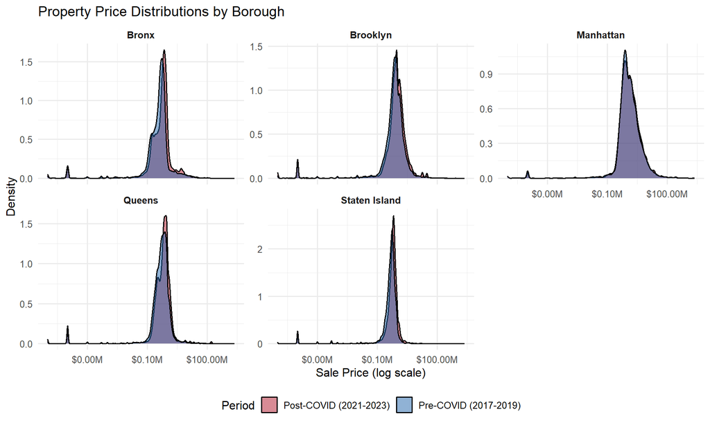

```r
sales_with_cd |>
  mutate(
    borough = case_when(
      substr(BoroCD, 1, 1) == "1" ~ "Manhattan", substr(BoroCD, 1, 1) == "2" ~ "Bronx",
      substr(BoroCD, 1, 1) == "3" ~ "Brooklyn", substr(BoroCD, 1, 1) == "4" ~ "Queens",
      substr(BoroCD, 1, 1) == "5" ~ "Staten Island"
    ),
    Period = ifelse(period == "pre", "Pre-COVID (2017-2019)", "Post-COVID (2021-2023)")
  ) |>
  ggplot(aes(x = sale_price, fill = Period)) +
  geom_density(alpha = 0.5) +
  facet_wrap(~borough, scales = "free_y") +
  scale_x_log10(labels = dollar_format(scale = 1e-6, suffix = "M")) +
  scale_fill_manual(values = c("Pre-COVID (2017-2019)" = "#2166ac", "Post-COVID (2021-2023)" = "#b2182b")) +
  labs(title = "Property Price Distributions by Borough", x = "Sale Price (log scale)", y = "Density") +
  theme_minimal(base_size = 12) +
  theme(legend.position = "bottom", strip.text = element_text(face = "bold"))
```

# 6 Analysis

With the data cleaned and explored, formal hypothesis testing was conducted to determine whether the job-price relationship changed after COVID.

Two approaches were used to measure job accessibility: one based on actual property locations and one based on CD centroids. The centroid approach provided a more stable measure not affected by which specific properties happened to sell in each period.

## 6.1 Job Accessibility Calculation

```r
job_blocks_pre <- lodes_blocks_centroids |>
  filter(year %in% 2017:2019) |>
  st_drop_geometry() |>
  group_by(GEOID) |>
  summarise(jobs_pre = mean(C000, na.rm = TRUE), .groups = "drop") |>
  left_join(lodes_blocks_centroids |> filter(year == 2019) |> select(GEOID, geometry), by = "GEOID") |>
  st_as_sf()

job_blocks_post <- lodes_blocks_centroids |>
  filter(year %in% 2021:2022) |>
  st_drop_geometry() |>
  group_by(GEOID) |>
  summarise(jobs_post = mean(C000, na.rm = TRUE), .groups = "drop") |>
  left_join(lodes_blocks_centroids |> filter(year == 2022) |> select(GEOID, geometry), by = "GEOID") |>
  st_as_sf()

calc_job_proximity <- function(sales_sf, job_blocks_sf, radius_m = 1000) {
  sales_proj <- st_transform(sales_sf, 2263)
  jobs_proj <- st_transform(job_blocks_sf, 2263)
  radius_ft <- radius_m * 3.28084
  sales_buffer <- st_buffer(sales_proj, dist = radius_ft)
  jobs_within <- st_join(sales_buffer, jobs_proj, join = st_intersects)
  job_col <- if("jobs_pre" %in% names(jobs_within)) "jobs_pre" else "jobs_post"
  jobs_within |>
    st_drop_geometry() |>
    group_by(bbl) |>
    summarise(jobs_within_1km = sum(.data[[job_col]], na.rm = TRUE), n_job_blocks = n(), .groups = "drop")
}

sales_pre <- sales_geo |> filter(period == "pre")
sales_post <- sales_geo |> filter(period == "post")

prox_pre <- calc_job_proximity(sales_pre, job_blocks_pre, radius_m = 1000)
prox_post <- calc_job_proximity(sales_post, job_blocks_post, radius_m = 1000)
```

```r
sales_pre_full <- sales_geo |> st_drop_geometry() |> filter(period == "pre") |> left_join(prox_pre, by = "bbl")
sales_post_full <- sales_geo |> st_drop_geometry() |> filter(period == "post") |> left_join(prox_post, by = "bbl")
sales_with_proximity <- bind_rows(sales_pre_full, sales_post_full)

cd_analysis <- sales_with_proximity |>
  mutate(BoroCD = cd) |>
  group_by(BoroCD, period) |>
  summarise(median_price = median(sale_price, na.rm = TRUE), avg_jobs_within_1km = mean(jobs_within_1km, na.rm = TRUE), n_sales = n(), .groups = "drop") |>
  pivot_wider(names_from = period, values_from = c(median_price, avg_jobs_within_1km, n_sales), names_sep = "_") |>
  mutate(
    price_change = median_price_post - median_price_pre,
    job_change = avg_jobs_within_1km_post - avg_jobs_within_1km_pre,
    price_change_pct = (median_price_post - median_price_pre) / median_price_pre * 100,
    job_change_pct = (avg_jobs_within_1km_post - avg_jobs_within_1km_pre) / avg_jobs_within_1km_pre * 100
  )

cd_analysis <- cd_shapes |> st_drop_geometry() |> select(BoroCD, cd_id, borough) |> left_join(cd_analysis, by = "BoroCD")
```

## 6.2 CD Centroid Job Accessibility

```r
lodes_pre <- lodes_blocks_centroids |> filter(year %in% 2017:2019) |> st_transform(2263) |>
  group_by(GEOID) |> summarise(jobs = mean(C000, na.rm = TRUE), geometry = first(geometry), .groups = "drop") |> st_as_sf()

lodes_post <- lodes_blocks_centroids |> filter(year %in% 2021:2022) |> st_transform(2263) |>
  group_by(GEOID) |> summarise(jobs = mean(C000, na.rm = TRUE), geometry = first(geometry), .groups = "drop") |> st_as_sf()

buffer_dist <- 3280.84

cd_centroids <- cd_shapes |> st_transform(2263) |> st_centroid()

cd_centroids$jobs_centroid_pre <- sapply(st_geometry(cd_centroids), function(x) {
  within_dist <- st_is_within_distance(st_sfc(x, crs = 2263), lodes_pre, dist = buffer_dist)
  sum(lodes_pre$jobs[within_dist[[1]]], na.rm = TRUE)
})

cd_centroids$jobs_centroid_post <- sapply(st_geometry(cd_centroids), function(x) {
  within_dist <- st_is_within_distance(st_sfc(x, crs = 2263), lodes_post, dist = buffer_dist)
  sum(lodes_post$jobs[within_dist[[1]]], na.rm = TRUE)
})

cd_analysis <- cd_analysis |>
  left_join(cd_centroids |> st_drop_geometry() |> select(BoroCD, jobs_centroid_pre, jobs_centroid_post), by = "BoroCD") |>
  mutate(jobs_centroid_change = jobs_centroid_post - jobs_centroid_pre,
         jobs_centroid_change_pct = (jobs_centroid_post - jobs_centroid_pre) / jobs_centroid_pre * 100)
```

## 6.3 Correlation Analysis

```r
cor_pre <- cor.test(cd_analysis$jobs_centroid_pre, cd_analysis$median_price_pre, use = "complete.obs")
cor_post <- cor.test(cd_analysis$jobs_centroid_post, cd_analysis$median_price_post, use = "complete.obs")

tibble(
  Period = c("Pre-COVID (2017-2019)", "Post-COVID (2021-2023)"),
  Correlation = round(c(cor_pre$estimate, cor_post$estimate), 3),
  `P-value` = format(c(cor_pre$p.value, cor_post$p.value), digits = 3, scientific = TRUE),
  `95% CI` = c(paste0("[", round(cor_pre$conf.int[1], 3), ", ", round(cor_pre$conf.int[2], 3), "]"),
               paste0("[", round(cor_post$conf.int[1], 3), ", ", round(cor_post$conf.int[2], 3), "]"))
) |>
  kbl(caption = "Correlation: Job Accessibility vs Median Property Values") |>
  kable_styling(bootstrap_options = c("striped", "hover"), full_width = FALSE)
```

Correlation: Job Accessibility vs Median Property Values

| Period | Correlation | P-value | 95% CI |
| --- | --- | --- | --- |
| Pre-COVID (2017-2019) | 0.630 | 8.88e-08 | [0.446, 0.763] |
| Post-COVID (2021-2023) | 0.618 | 1.80e-07 | [0.43, 0.755] |

The correlation analysis serves as the main test for H1. Both periods show strong positive correlations (r = 0.630 pre-COVID and r = 0.618 post-COVID), and both are highly significant with p-values well below 0.05. The key finding is that the correlation barely changed, going from 0.630 to 0.618. Neighborhoods with more jobs nearby still command higher prices after COVID, just as they did before.

## 6.4 Fisher’s Z-Test

```r
fisher_z <- function(r) 0.5 * log((1 + r) / (1 - r))
z_pre <- fisher_z(cor_pre$estimate)
z_post <- fisher_z(cor_post$estimate)
n <- nrow(cd_analysis)
se_diff <- sqrt(1/(n-3) + 1/(n-3))
z_stat <- (z_pre - z_post) / se_diff
p_fisher <- 2 * (1 - pnorm(abs(z_stat)))

tibble(
  Metric = c("Pre-COVID Fisher Z", "Post-COVID Fisher Z", "Z-statistic", "P-value"),
  Value = c(round(z_pre, 3), round(z_post, 3), round(z_stat, 3), round(p_fisher, 4))
) |>
  kbl(caption = "Fisher's Z-Test: Did the Correlation Change Significantly?") |>
  kable_styling(bootstrap_options = c("striped", "hover"), full_width = FALSE)
```

Fisher's Z-Test: Did the Correlation Change Significantly?

| Metric | Value |
| --- | --- |
| Pre-COVID Fisher Z | 0.7420 |
| Post-COVID Fisher Z | 0.7220 |
| Z-statistic | 0.1030 |
| P-value | 0.9181 |

To formally test whether the small drop in correlation was statistically meaningful, Fisher’s Z-test was applied. The p-value was 0.92, well above the 0.05 threshold, meaning the null hypothesis (that the two correlations are equal) could not be rejected. The tiny change from r = 0.63 to r = 0.62 was within normal sampling variability, which does not support hypothesis H1.

## 6.5 Manhattan vs Outer Boroughs

```r
cd_analysis <- cd_analysis |> mutate(area = ifelse(borough == "Manhattan", "Manhattan", "Outer Boroughs"))
manhattan <- cd_analysis |> filter(area == "Manhattan")
outer <- cd_analysis |> filter(area == "Outer Boroughs")

tibble(
  Area = c("Manhattan", "Outer Boroughs"),
  `Pre-COVID r` = round(c(cor(manhattan$jobs_centroid_pre, manhattan$median_price_pre, use = "complete.obs"),
                          cor(outer$jobs_centroid_pre, outer$median_price_pre, use = "complete.obs")), 3),
  `Post-COVID r` = round(c(cor(manhattan$jobs_centroid_post, manhattan$median_price_post, use = "complete.obs"),
                           cor(outer$jobs_centroid_post, outer$median_price_post, use = "complete.obs")), 3)
) |>
  mutate(Change = `Post-COVID r` - `Pre-COVID r`) |>
  kbl(caption = "Correlation Changes: Manhattan vs Outer Boroughs") |>
  kable_styling(bootstrap_options = c("striped", "hover"), full_width = FALSE)
```

Correlation Changes: Manhattan vs Outer Boroughs

| Area | Pre-COVID r | Post-COVID r | Change |
| --- | --- | --- | --- |
| Manhattan | 0.618 | 0.663 | 0.045 |
| Outer Boroughs | 0.413 | 0.449 | 0.036 |

H2 predicted that the job-price relationship would weaken more in Manhattan than the outer boroughs. The results show the opposite: the correlation actually strengthened in both Manhattan (+0.045) and the outer boroughs (+0.036). Instead of job accessibility becoming less important, it became slightly more important after COVID, directly contradicting H2. One possible explanation is that as remote work reduced commuting frequency, people valued being near job centers for occasional office days or for the amenities that cluster around employment hubs.

## 6.6 Difference-in-Differences Regression

```r
cd_long <- cd_analysis |>
  select(BoroCD, cd_id, borough, jobs_centroid_pre, jobs_centroid_post, median_price_pre, median_price_post) |>
  pivot_longer(cols = c(jobs_centroid_pre, jobs_centroid_post, median_price_pre, median_price_post),
               names_to = c(".value", "period"), names_pattern = "(.*)_(pre|post)") |>
  mutate(period = factor(period, levels = c("pre", "post")))

model_did <- lm(median_price ~ jobs_centroid * period, data = cd_long)

broom::tidy(model_did) |>
  mutate(term = case_when(
    term == "(Intercept)" ~ "Intercept", term == "jobs_centroid" ~ "Jobs within 1km",
    term == "periodpost" ~ "Post-COVID Period", term == "jobs_centroid:periodpost" ~ "Jobs × Post (Interaction)"
  )) |>
  select(Term = term, Estimate = estimate, `Std. Error` = std.error, `t-value` = statistic, `P-value` = p.value) |>
  mutate(across(where(is.numeric), ~round(., 3))) |>
  kbl(caption = "Difference-in-Differences Regression Results") |>
  kable_styling(bootstrap_options = c("striped", "hover"), full_width = FALSE)
```

Difference-in-Differences Regression Results

| Term | Estimate | Std. Error | t-value | P-value |
| --- | --- | --- | --- | --- |
| Intercept | 674547.522 | 38699.263 | 17.431 | 0.000 |
| Jobs within 1km | 1.878 | 0.297 | 6.320 | 0.000 |
| Post-COVID Period | 105337.280 | 54882.104 | 1.919 | 0.057 |
| Jobs × Post (Interaction) | 0.028 | 0.445 | 0.062 | 0.951 |

The difference-in-differences regression provides another way to test whether the job-price relationship changed. The interaction term “Jobs × Post” is the key coefficient, measuring whether the effect of job accessibility on prices differed between periods. The coefficient was essentially zero (0.028) with a p-value of 0.95, well above 0.05, meaning the null hypothesis (that the relationship did not change) could not be rejected. The “Jobs within 1km” coefficient shows that each additional nearby job was associated with about $1.88 higher property value pre-COVID, and that relationship remained unchanged post-COVID.

## 6.7 Price Growth by Accessibility Level

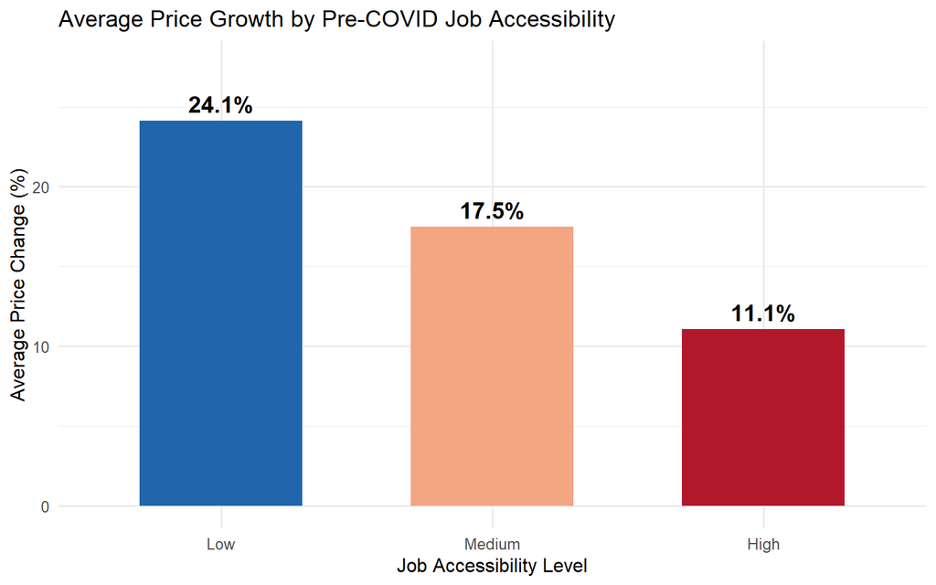

Average price growth by pre-COVID job accessibility tercile

```r
cd_analysis <- cd_analysis |>
  mutate(access_level = ntile(avg_jobs_within_1km_pre, 3),
         access_label = factor(case_when(access_level == 1 ~ "Low", access_level == 2 ~ "Medium", access_level == 3 ~ "High"),
                               levels = c("Low", "Medium", "High")),
         price_change_pct = (median_price_post - median_price_pre) / median_price_pre * 100)

access_summary <- cd_analysis |>
  group_by(access_label) |>
  summarise(n_cds = n(), avg_price_change_pct = mean(price_change_pct, na.rm = TRUE), .groups = "drop")

ggplot(access_summary, aes(x = access_label, y = avg_price_change_pct, fill = access_label)) +
  geom_col(width = 0.6) +
  geom_text(aes(label = paste0(round(avg_price_change_pct, 1), "%")), vjust = -0.5, size = 5, fontface = "bold") +
  scale_fill_manual(values = c("Low" = "#2166ac", "Medium" = "#f4a582", "High" = "#b2182b")) +
  labs(title = "Average Price Growth by Pre-COVID Job Accessibility", x = "Job Accessibility Level", y = "Average Price Change (%)") +
  theme_minimal(base_size = 12) + theme(legend.position = "none") +
  ylim(0, max(access_summary$avg_price_change_pct, na.rm = TRUE) * 1.15)
```

H3 was the one hypothesis that received support. Neighborhoods were split into terciles based on pre-COVID job accessibility, then average price growth was compared across groups. Low-accessibility neighborhoods had the highest price growth, followed by medium, then high. Even though the overall correlation between job accessibility levels and price levels remained stable, neighborhoods farther from jobs saw larger percentage price increases. Remote work may have made it easier for buyers to consider locations that were previously less desirable due to long commutes.

# 7 Visualizations

## 7.1 Interactive Map: Pre vs Post COVID Prices

```r
cd_map <- cd_shapes |> left_join(cd_analysis, by = c("BoroCD", "cd_id", "borough")) |> st_transform(4326)

pal_price_pre <- colorNumeric(palette = "RdYlGn", domain = cd_map$median_price_pre)

cd_map$label_pre <- paste0("<strong>", cd_map$cd_id, " (", cd_map$borough, ")</strong><br>",
                           "<b>Pre-COVID:</b><br>Jobs within 1km: ", scales::comma(round(cd_map$avg_jobs_within_1km_pre, 0)), "<br>",
                           "Median Price: $", scales::comma(round(cd_map$median_price_pre, 0)), "<br>",
                           "<b>Change:</b><br>Job Change: ", round(cd_map$job_change_pct, 1), "%<br>Price Change: ", round(cd_map$price_change_pct, 1), "%")

cd_map$label_post <- paste0("<strong>", cd_map$cd_id, " (", cd_map$borough, ")</strong><br>",
                            "<b>Post-COVID:</b><br>Jobs within 1km: ", scales::comma(round(cd_map$avg_jobs_within_1km_post, 0)), "<br>",
                            "Median Price: $", scales::comma(round(cd_map$median_price_post, 0)), "<br>",
                            "<b>Change:</b><br>Job Change: ", round(cd_map$job_change_pct, 1), "%<br>Price Change: ", round(cd_map$price_change_pct, 1), "%")

leaflet(cd_map) |>
  addProviderTiles("CartoDB.Positron") |>
  addPolygons(fillColor = ~pal_price_pre(median_price_pre), fillOpacity = 0.7, color = "black", weight = 1,
              label = ~lapply(label_pre, htmltools::HTML), group = "Pre-COVID (2017-2019)") |>
  addPolygons(fillColor = ~pal_price_pre(median_price_post), fillOpacity = 0.7, color = "black", weight = 1,
              label = ~lapply(label_post, htmltools::HTML), group = "Post-COVID (2021-2023)") |>
  addLayersControl(baseGroups = c("Pre-COVID (2017-2019)", "Post-COVID (2021-2023)"), options = layersControlOptions(collapsed = FALSE)) |>
  addLegend(pal = pal_price_pre, values = ~median_price_pre, title = "Median Price ($)", position = "bottomright",
            labFormat = labelFormat(prefix = "$", big.mark = ",")) |>
  setView(lng = -73.95, lat = 40.7, zoom = 10)
```

[interactive chart not shown]

The interactive map allows exploration of how prices changed across different neighborhoods. Toggling between pre and post-COVID shows the shift, and hovering over any district displays the details. Although prices increased nearly everywhere, the relative ranking of neighborhoods remained stable: expensive areas before COVID were still expensive after.

## 7.2 Scatter Plot: Job Accessibility vs Median Price

```r
cor_pre_val <- cor(cd_analysis$avg_jobs_within_1km_pre, cd_analysis$median_price_pre, use = "complete.obs")
cor_post_val <- cor(cd_analysis$avg_jobs_within_1km_post, cd_analysis$median_price_post, use = "complete.obs")

plot_ly() |>
  add_trace(data = cd_analysis, x = ~avg_jobs_within_1km_pre, y = ~median_price_pre, type = "scatter", mode = "markers",
            name = paste0("Pre-COVID (r = ", round(cor_pre_val, 2), ")"), marker = list(color = "blue", size = 10, opacity = 0.7),
            text = ~paste0(cd_id, " (", borough, ")<br>Jobs: ", scales::comma(round(avg_jobs_within_1km_pre, 0)), "<br>Price: $", scales::comma(round(median_price_pre, 0))),
            hoverinfo = "text") |>
  add_trace(data = cd_analysis, x = ~avg_jobs_within_1km_post, y = ~median_price_post, type = "scatter", mode = "markers",
            name = paste0("Post-COVID (r = ", round(cor_post_val, 2), ")"), marker = list(color = "red", size = 10, opacity = 0.7),
            text = ~paste0(cd_id, " (", borough, ")<br>Jobs: ", scales::comma(round(avg_jobs_within_1km_post, 0)), "<br>Price: $", scales::comma(round(median_price_post, 0))),
            hoverinfo = "text") |>
  layout(title = "Job Accessibility vs Property Values (Pre vs Post COVID)",
         xaxis = list(title = "Average Jobs within 1km"), yaxis = list(title = "Median Sale Price ($)", tickformat = "$,"))
```

[interactive chart not shown]

The scatter plot displays both periods side by side. The blue dots (pre-COVID) and red dots (post-COVID) follow similar patterns, with strong positive relationships between jobs and prices in both periods. The red dots are generally shifted upward since prices increased everywhere, but the slope of the relationship appears unchanged.

## 7.3 Bivariate Map: Job Change vs Price Change

```r
cd_map <- cd_map |>
  mutate(job_dir = ifelse(job_change_pct > 0, "Jobs Up", "Jobs Down"),
         price_dir = ifelse(price_change_pct > 0, "Price Up", "Price Down"),
         quadrant = paste(job_dir, "/", price_dir),
         quad_color = case_when(quadrant == "Jobs Up / Price Up" ~ "#1a9850", quadrant == "Jobs Down / Price Down" ~ "#d73027",
                                quadrant == "Jobs Up / Price Down" ~ "#fdae61", quadrant == "Jobs Down / Price Up" ~ "#9970ab", TRUE ~ "#grey"))

cd_map$label_bivar <- paste0("<strong>", cd_map$cd_id, " (", cd_map$borough, ")</strong><br>",
                             "Job Change: ", round(cd_map$job_change_pct, 1), "%<br>Price Change: ", round(cd_map$price_change_pct, 1), "%<br><b>", cd_map$quadrant, "</b>")

leaflet(cd_map) |>
  addProviderTiles("CartoDB.Positron") |>
  addPolygons(fillColor = ~quad_color, fillOpacity = 0.7, color = "black", weight = 1, label = ~lapply(label_bivar, htmltools::HTML)) |>
  addLegend(colors = c("#1a9850", "#d73027", "#fdae61", "#9970ab"),
            labels = c("Jobs Up / Price Up", "Jobs Down / Price Down", "Jobs Up / Price Down", "Jobs Down / Price Up"),
            title = "Change Pattern", position = "bottomright") |>
  setView(lng = -73.95, lat = 40.7, zoom = 10)
```

[interactive chart not shown]

## 7.4 Job Change vs Price Change

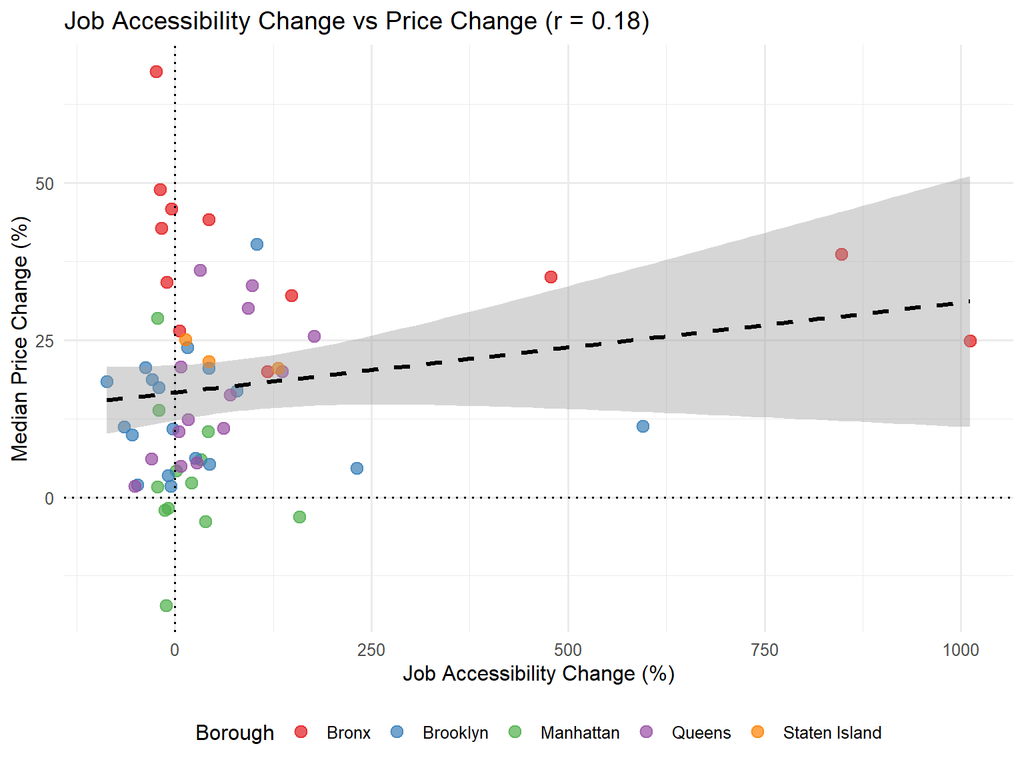

Relationship between job accessibility changes and price changes

```r
change_cor <- cor(cd_analysis$job_change_pct, cd_analysis$price_change_pct, use = "complete.obs")

ggplot(cd_analysis, aes(x = job_change_pct, y = price_change_pct, color = borough)) +
  geom_point(size = 3, alpha = 0.7) +
  geom_smooth(method = "lm", se = TRUE, color = "black", linetype = "dashed") +
  geom_hline(yintercept = 0, linetype = "dotted") + geom_vline(xintercept = 0, linetype = "dotted") +
  scale_color_brewer(palette = "Set1") +
  labs(title = paste0("Job Accessibility Change vs Price Change (r = ", round(change_cor, 2), ")"),
       x = "Job Accessibility Change (%)", y = "Median Price Change (%)", color = "Borough") +
  theme_minimal(base_size = 12) + theme(legend.position = "bottom")
```

# 8 Conclusion

## 8.1 Summary of Findings

My analysis examined whether COVID-19 changed the relationship between job accessibility and property values across NYC’s 59 Community Districts. Three hypotheses were tested using LODES employment data, DOF sales data, and Census geography.

**Finding 1: The job-price correlation stayed stable (H1 not supported).** The correlation went from r = 0.63 before COVID to r = 0.62 after. Fisher’s Z-test produced a p-value of 0.92, well above 0.05, so the null hypothesis that the correlations are equal could not be rejected. Neighborhoods near jobs still commanded higher prices after COVID, just as before.

**Finding 2: Manhattan and outer boroughs both showed stronger correlations (H2 not supported).** The expectation was that Manhattan would show a greater weakening of the job-price relationship since it has more remote-work-friendly jobs. Instead, both Manhattan (+0.045) and the outer boroughs (+0.036) showed slightly stronger correlations after COVID. The difference-in-differences regression confirmed this: the interaction term had a p-value of 0.95, so the null hypothesis of no change could not be rejected.

**Finding 3: Low-accessibility neighborhoods had higher price growth (H3 supported).** When neighborhoods were grouped by pre-COVID job accessibility, the low-accessibility group had the highest percentage price growth. This supported H3 and suggested that remote work may have made it easier for buyers to move to areas previously considered too far from jobs.

## 8.2 Contribution to Overarching Question

My analysis contributes to our team’s overarching question about whether COVID-19 reshaped the relationship between neighborhood characteristics and property values. For job accessibility specifically, the answer is nuanced. The basic relationship, where neighborhoods near jobs have higher prices, remained remarkably stable. However, the pattern of price growth did shift toward lower-accessibility areas. COVID-19 may have expanded the set of neighborhoods buyers would consider, even if it did not eliminate the premium for being near jobs.

## 8.3 Limitations

Several considerations should be kept in mind when interpreting these results. First, analyzing at the community district level may hide variation within neighborhoods; a property-level analysis could reveal different patterns. Second, 2023 employment had to be estimated using ZIP Code Business Patterns growth rates since actual LODES data was not yet available. Third, the mix of properties that sold may have differed between periods, which could affect price comparisons. Finally, other factors that changed during COVID, such as crime rates, school quality, and transit access, might explain some of the observed patterns.